# Multivariate time series, VAR and state space models

ARIMA models and the Box-Jenkins approach are the benchmark for modeling univariate time series. But, when we have more than one time series and presume they both affect each other, how can we take this into account for a statistical model?

In the case we want to model multiple time series and cannot assume exogeneity, we need to make use of statistical models where the series are endogenous to each other, i.e. the realized values of one series influences the future values of other series.

```python
import numpy as np
import pandas as pd
import matplotlib.pyplot as plt
import scipy.stats as st
import statsmodels.api as sm
import seaborn as sns
import yfinance as yf
import pymc as pm
import arviz as az
%matplotlib inline
```

[output not shown]

The most famous of such models is the vector autoregression, or VAR. The VAR assumes endogeneity between variables, which means the past values for one variable determines present values of the other variable. For a bivariate VAR(1), this would look like

$x_t = \phi_{11} x_{t-1} + \phi_{12} y_{t-1} + \varepsilon_{1t}$,

$y_t = \phi_{21} x_{t-1} + \phi_{22} y_{t-1} + \varepsilon_{2t}$,

assuming no constant terms for either process. It is also common to use matrix notation for VAR models, as, in higher dimensional settings, this makes notation much easier to read. The same VAR in matrix notation could be expressed as

$\textbf{y}_t = A \textbf{y}_{t-1} + \boldsymbol{\varepsilon}_t$,

$\textbf{y}_t = \begin{bmatrix} y_{1t} \\ y_{2t} \end{bmatrix}$, $A = \begin{bmatrix} \phi_{11} & \phi_{12} \\ \phi_{21} & \phi_{22} \end{bmatrix}$, $\boldsymbol{\varepsilon}_t \sim N(\textbf{0}, \Sigma_\varepsilon)$,

where $\Sigma_\varepsilon$ is the covariance matrix of the errors.

Just like the univariate AR, a VAR needs to satisfy stationarity conditions. In the matrix notation, the stationarity condition for a bivariate VAR(1) process can be expressed as

$|A - \Lambda I_p| = 0$,

where $I_p$ is an identity matrix of order $p$ (in our case $p = 2$ because the VAR is bivariate) and $\Lambda$ is the diagonal matrix of the $p$ eigenvalues obtained from the spectral decomposition $A = \textbf{V} \Lambda \textbf{V}^{-1}$, where $\textbf{V}$ is the matrix composed of the $p$ eigenvectors. A VAR, just like the AR process, can also be represented as a (vector) moving average.

One of the main functions of VAR models is forecasting of one variable in function of the others. Forecasts in the VAR framework are generated recursively, meaning we obtain forecasts of future variables plugging in the past observed values plus the estimated parameters. The error covariance can also be used to generate prediction intervals and forecast error measures such as MSE.

Besides generating predictions for out-of-sample observations, we can also check how our model explains the data in our sample. This is known as structural analysis, and we present 3 ways for it: variance decomposition, impulse-response functions and Granger causality.

So far, the type of VAR model we have been analyzing is the reduced-form VAR, as each equation only has one variable at time $t$, disregarding the simultaneous effect one variable can have on another. Actually, this simultaneity is present in the errors, which cannot be interpreted as exogenous shocks to each variable, as both exogenous shocks to each variable ate tied together in the reduced-form errors. In order to have causal interpretations about the model shocks, we need a structural-form VAR (SVAR), which in turn requires identification restrictions. Structural analysis is best employed when analyzing a structural VAR, but here we perform structural analysis for the reduced-form VAR.

The variance decomposition procedure consists of decomposing the forecasting error variance so that we can see how much of it is explained by shocks in each of the variables, attributing a corresponding percentage. Once again, the causal intepretation is limited as we are looking at the reduced-form VAR.

Impulse-response functions (IRF) are obtained so we can visualize the impact of a shock to one variable to each of the variables along time. Remembering that, as we are using the reduced-form VAR, these shocks, and therefore the IRFs, do not have a causal interpretation. The IRF relies on the vector moving average representation of the VAR, as a VAR(1) model can be written as a vector moving average of order infinity, and a VAR of any order $p$ can be rewritten to be represented as a VAR(1) using a companion form. If the stationarity conditions are met, the response to the shocks will dissipate over time, becoming closer to zero.

Granger causality is a type of statistical test that allows us to test if each variable is useful in determining the others within our sample. Besides what the name suggests, it is hard to draw causal interpretations solely out of Granger causality tests because the out-of-sample extrapolation is limited and also we are using the reduced-form VAR.

We can estimate a VAR, perform structural analysis and generate forecasts with the statsmodels library

```python
start_date = "2017-01-01"
end_date = "2022-06-01"

cvx = yf.Ticker("CVX").history(start = start_date, end = end_date)["Close"].rename("CVX").interpolate()
wti = yf.Ticker("CRUD.L").history(start = start_date, end = end_date)["Close"].rename("WTI")
icln = yf.Ticker("ICLN").history(start = start_date, end = end_date)["Close"].rename("ICLN")
cvx_diff = np.log(cvx).diff().dropna()
wti_diff = np.log(wti).diff().dropna()
icln_diff = np.log(icln).diff().dropna()

var_data = pd.DataFrame([cvx_diff,wti_diff,icln_diff]).T.dropna()
```

```python
model = sm.tsa.VAR(var_data)
results = model.fit(1)
results.summary()
```

```
  Summary of Regression Results
==================================
Model:                         VAR
Method:                        OLS
Date:           Wed, 05, Oct, 2022
Time:                     12:13:01
--------------------------------------------------------------------
No. of Equations:         3.00000    BIC:                   -23.5774
Nobs:                     1336.00    HQIC:                  -23.6066
Log likelihood:           10105.8    FPE:                5.49767e-11
AIC:                     -23.6241    Det(Omega_mle):     5.44858e-11
--------------------------------------------------------------------
Results for equation CVX
==========================================================================
             coefficient       std. error           t-stat            prob
--------------------------------------------------------------------------
const           0.000411         0.000570            0.721           0.471
L1.CVX         -0.117853         0.034871           -3.380           0.001
L1.WTI         -0.019872         0.024910           -0.798           0.425
L1.ICLN        -0.023715         0.036271           -0.654           0.513
==========================================================================

Results for equation WTI
==========================================================================
             coefficient       std. error           t-stat            prob
--------------------------------------------------------------------------
const           0.000183         0.000731            0.251           0.802
L1.CVX          0.053208         0.044776            1.188           0.235
L1.WTI          0.000234         0.031985            0.007           0.994
L1.ICLN        -0.007347         0.046575           -0.158           0.875
==========================================================================

Results for equation ICLN
==========================================================================
             coefficient       std. error           t-stat            prob
--------------------------------------------------------------------------
const           0.000688         0.000489            1.407           0.159
L1.CVX         -0.130563         0.029925           -4.363           0.000
L1.WTI          0.005815         0.021377            0.272           0.786
L1.ICLN         0.063836         0.031127            2.051           0.040
==========================================================================

Correlation matrix of residuals
             CVX       WTI      ICLN
CVX     1.000000  0.527162  0.481536
WTI     0.527162  1.000000  0.284654
ICLN    0.481536  0.284654  1.000000
```

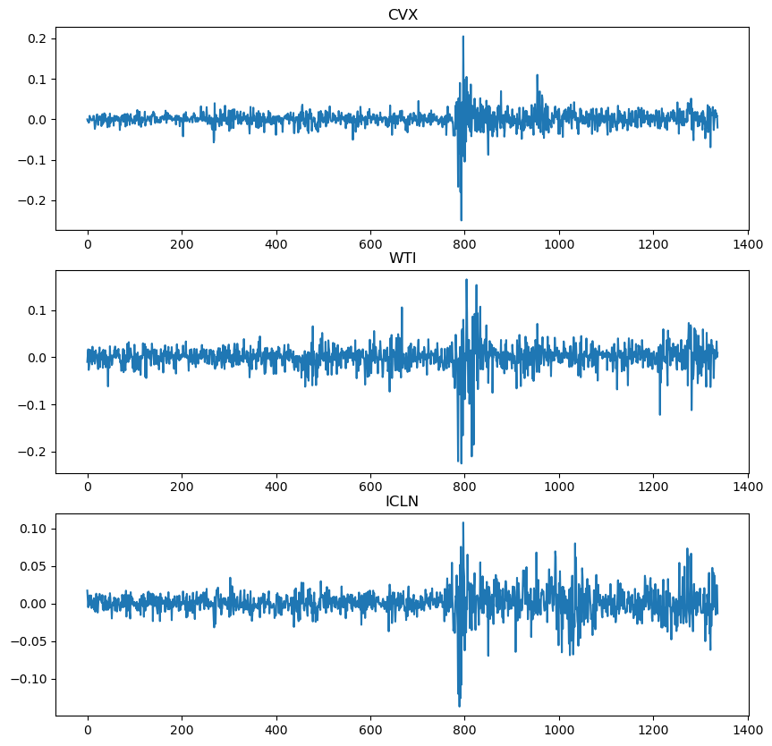

```python
results.plot()
plt.show()
```

```python
results.forecast(var_data.values[-1:], 10)
```

```
array([[ 2.95572803e-03, -8.10674216e-04,  2.58950239e-03],
       [ 1.69884678e-05,  3.21294762e-04,  4.62373368e-04],
       [ 3.91277962e-04,  1.80824147e-04,  7.16860997e-04],
       [ 3.43923098e-04,  1.98836639e-04,  6.83421024e-04],
       [ 3.49939093e-04,  1.96566894e-04,  6.87573918e-04],
       [ 3.49176709e-04,  1.96855949e-04,  6.87040353e-04],
       [ 3.49273467e-04,  1.96819372e-04,  6.87107513e-04],
       [ 3.49261198e-04,  1.96824019e-04,  6.87098954e-04],
       [ 3.49262755e-04,  1.96823430e-04,  6.87100037e-04],
       [ 3.49262557e-04,  1.96823505e-04,  6.87099899e-04]])
```

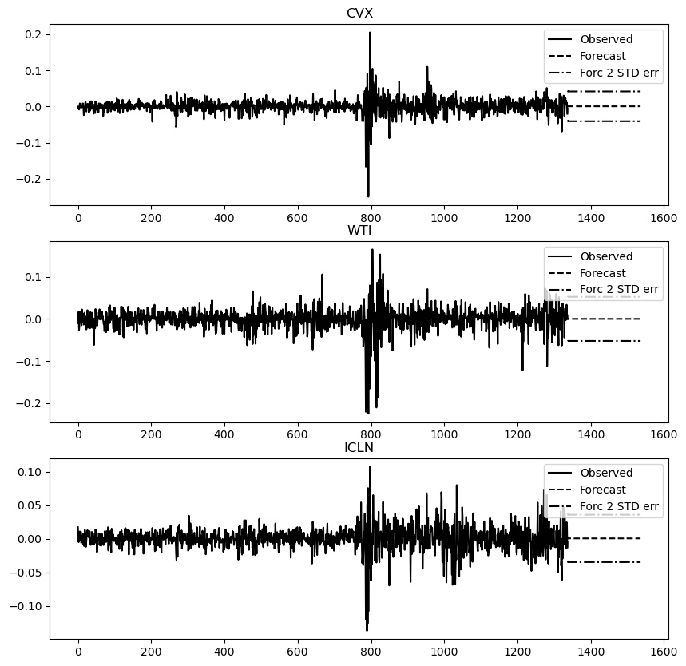

```python
results.plot_forecast(200)
plt.show()
```

```python
fevd = results.fevd(10)
fevd.summary()
```

```
FEVD for CVX
          CVX       WTI      ICLN
0    1.000000  0.000000  0.000000
1    0.999196  0.000493  0.000311
2    0.999190  0.000498  0.000312
3    0.999189  0.000498  0.000312
4    0.999189  0.000498  0.000312
5    0.999189  0.000498  0.000312
6    0.999189  0.000498  0.000312
7    0.999189  0.000498  0.000312
8    0.999189  0.000498  0.000312
9    0.999189  0.000498  0.000312

FEVD for WTI
          CVX       WTI      ICLN
```

[output cut: 23 more lines]

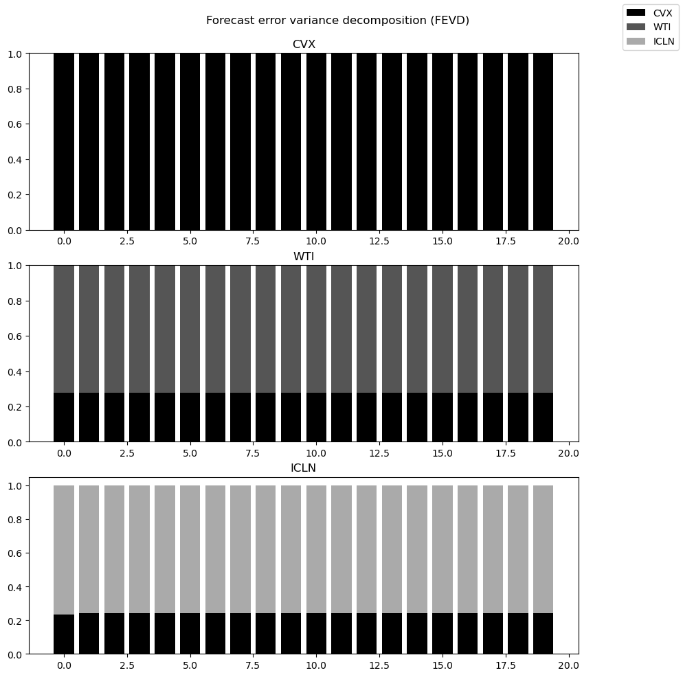

```python
results.fevd(20).plot()
plt.show()
```

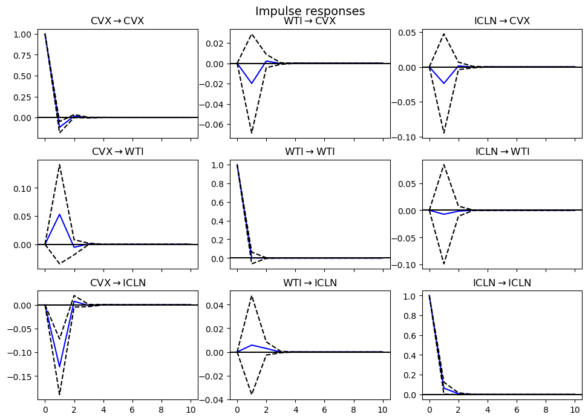

```python
irf = results.irf(10)
irf.plot(orth=False, figsize=(10,7))
plt.show()
```

```python
results.test_causality('CVX', ['WTI', 'ICLN'], kind='f').summary()
```

Granger causality F-test. H_0: ['WTI', 'ICLN'] do not Granger-cause CVX. Conclusion: fail to reject H_0 at 5% significance level.

| Test statistic | Critical value | p-value | df |
| --- | --- | --- | --- |
| 0.5504 | 2.998 | 0.577 | (2, 3996) |

```python
results.test_causality('WTI', 'CVX', kind='f').summary()
```

Granger causality F-test. H_0: CVX does not Granger-cause WTI. Conclusion: fail to reject H_0 at 5% significance level.

| Test statistic | Critical value | p-value | df |
| --- | --- | --- | --- |
| 1.412 | 3.844 | 0.235 | (1, 3996) |

Both classical and Bayesian statistics provides us with tools for estimating the parameters of a VAR. For the frequentist (classical) approach, we can estimate the parameters of the model by a least squares regression, provided the stationarity conditions are met.

The classical estimation of VARs also relies on having a large amount of data, especially in models with many parameters. In this setting, where you have many parameters and few observations, least squares estimation becomes unfeasible. Bayesian estimation can provide a solution to this, as the prior distribution specification allows for more flexibility in model specification, and also allows for the use of shrinkage. See: https://kevinkotze.github.io/ts-9-bvar/

As a VAR usually has a large number of parameters, we resort to computational methods for Bayesian estimation. The Gibbs sampler is a very commonly used Bayesian computation routine where sampling is based on the conditional distributions of the posteriors, which makes it much easier than sampling from the joint distribution of parameters in models with many parameters. In a Gibbs sampling routine, we sample each parameter at a time while conditioning on all of the others. For example, in case we have three parameters, a Gibbs sampler would draw samples from

1. $P(\theta_1 | \theta_2, \theta_3)$
2. $P(\theta_2 | \theta_1, \theta_3)$
3. $P(\theta_3 | \theta_2, \theta_3)$

successively until we have enough draws to estimate the posterior distribution of the parameters. This is quite easy to implement if we have conjugate posteriors for all of the parameters.

Whenever the closed form posterior for a given parameter is not available, we can resort to Metropolis-Hastings (MH) algorithms. MH consists of sampling a value from a proposal distribution (usually a normal), calculating the target posterior density for the parameter at the proposed value, and compare it to the target density at the previous value accepting or rejecting the new proposed value. A Metropolis-Hastings algorithm can be written as

1. Specify a proposal distribution $Q(.)$, for example $N(\theta, \sigma_{MH})$, where $\sigma_{MH}$ is chosen so our sampler explores the posterior distribution well enough. It is important that the $Q$ distribution is symmetric, that is, for mean values $\theta$ and $\theta^*$ we have $Q(\theta^* | \theta) = Q(\theta | \theta^*)$, and the normal distribution satisfies this.
2. Sample a proposed value $\theta^*$ from $Q(\theta^*)$ and calculate the ratio $\alpha = \frac{f(\theta^*)}{f(\theta)}$, where $f(.)$ is the target distribution we want to sample from and $\theta$ is the previous value.
3. Sample $u \sim U(0,1)$ and accept $\theta^*$ if $\alpha > u$, reject otherwise.
4. In case $\theta^*$ is accepted, it becomes the new $\theta$ and the algorithm is repeated until we get enough draws from the target posterior distribution.

Now that we know a few ways we can sample from posteriors, we turn our attention into how to specify priors. Conjugate priors are advantageous, as it allows us to write Gibbs samplers in a simple fashion. It may also be desirable to specify shrinkage priors, turning our inference more robust to extreme observations.

In the case of the Bayesian VARs (BVARs), the Minnesota prior is perhaps the most famous prior distribution. It is a shrinkage prior, allowing us to control the strength of the shrinkage effect (the "tightness") through the hyperparameters. The Minnesota prior incorporates the prior belief that the variables follow a random walk process, which is a reasonable starting point given the empirical evidence that many macroeconomic time series behave like unit root processes (http://hedibert.org/wp-content/uploads/2015/03/nelson-plosser-1982.pdf).

Suppose we have a bivariate VAR(1)

$y_{1,t} = c_1 + \phi_{11} y_{1,t-1} + \phi_{12} y_{2,t-1} + \varepsilon_{1,t}$,

$y_{2,t} = c_2 + \phi_{21} y_{1,t-1} + \phi_{22} y_{2,t-1} + \varepsilon_{2,t}$,

and our parameters are the intercepts and coefficients $\Theta = (c_1,\phi_{11},\phi_{12},c_2,\phi_{21},\phi_{22})$, plus the covariance matrix for the error terms, $\Sigma$.

The variables $y_{1,t}$ and $y_{2,t}$ behaving like random walks would imply that $c_1$,$c_2$,$\phi_{12}$ and $\phi_{21}$ are all equal to zero, and $\phi_{11}$ and $\phi_{22}$ equal to 1. The hyperparameters of the prior mean for the VAR intercepts and coefficients under the Minnesota prior are chosen to reflect this belief.

As for the prior variance, the Minnesota prior allows us to control the tightness around the prior mean, that is, the size of the shrinkage effect. In our example, we can write the Minnesota prior as

$\Theta = (c_1,\phi_{11},\phi_{12},c_2,\phi_{21},\phi_{22})$,

$p(\Theta) \sim N(\bar{\theta}, H)$,

$\bar{\theta} = [0,1,0,0,0,1]$,

$H = \operatorname{diag} \bigg( (\sigma_1 \lambda_c)^2, \lambda_1^2, \big(\frac{\sigma_1 \lambda_1 \lambda_2}{\sigma_2}\big)^2, (\sigma_2 \lambda_c)^2, \big(\frac{\sigma_2 \lambda_1 \lambda_2}{\sigma_1}\big)^2, \lambda_1^2 \bigg) $,

where index $i$ refers to the equation (and dependent variable within that equation) and index $j$ to the independent variable, $\sigma_i$ and $\sigma_j$ to the variances of AR regression error terms estimated via OLS, and $\lambda_1$, $\lambda_2$ and $\lambda_c$ refer to the tightness hyperparameters for lags of the dependent variables, independent variables and constant terms. A more thorough explanation, together with examples for higher order VARs can be found at https://www.bankofengland.co.uk/-/media/boe/files/ccbs/resources/applied-bayesian-econometrics-for-central-bankers-updated-2017.pdf

As for $\Sigma$, the covariance matrix for the error terms, we can give it a standard conjugate prior, such as an inverse Wishart, for example.

Here we implement a Gibbs sampling routine for a Bayesian VAR heavily inspired from section 2.1 of chapter 2 of https://www.bankofengland.co.uk/-/media/boe/files/ccbs/resources/applied-bayesian-econometrics-for-central-bankers-updated-2017.pdf

```python
np.random.seed(1)

bvar_data = pd.DataFrame([cvx_diff,wti_diff]).T.dropna()
Y = bvar_data.values
X = np.insert(bvar_data[:-1].values, 0, [0,0], axis=0)
X = np.insert(X.T, 0, np.ones(len(X)), axis=0).T

# hyperparameters

lamb_c = 1e2
lamb_1 = 0.2
lamb_2 = 0.5

model = sm.tsa.VAR(bvar_data)
results = model.fit(1)
Sigma = results.sigma_u

sigma_1 = np.sqrt(Sigma.values[0][0])
sigma_2 = np.sqrt(Sigma.values[1][1])

theta_bar = np.array([0,1,0,0,0,1])
H = np.diag([(sigma_1 * lamb_c)**2, (lamb_1)**2, ((sigma_1*lamb_1*lamb_2)/sigma_2)**2, (sigma_2 * lamb_c)**2, ((sigma_2*lamb_1*lamb_2)/sigma_1)**2, (lamb_1)**2])

theta_hat = (np.linalg.inv(X.T @ X) @ (X.T @ Y)).flatten()

S_bar = np.eye(2)
alpha_df = 3

# initialize objects to store sampled values
n_samples = 1000
theta_sampled = np.empty([n_samples, 6])
Sigma_sampled = np.empty([n_samples, 2, 2])

# sampler
for i in range(0, n_samples):
    # step 1: sample coefficients conditional on covariance matrix Sigma
    M_star = np.linalg.inv(np.linalg.inv(H) + np.kron(np.linalg.inv(Sigma) , X.T @ X)) @ (np.linalg.inv(H) @ theta_bar + np.kron(np.linalg.inv(Sigma) , X.T @ X) @ theta_hat)
    V_star = np.linalg.inv(np.linalg.inv(H) + np.kron(np.linalg.inv(Sigma) , X.T @ X))
    theta = np.random.multivariate_normal(M_star, V_star)
    theta_sampled[i] = theta

    # step 2: sample covariance matrix Sigma
    theta_matrix = theta.reshape(2,3).T
    Sigma_bar = S_bar + (Y - (X @ theta_matrix)).T @ (Y - (X @ theta_matrix))
    Sigma = st.invwishart.rvs(alpha_df+len(Y), Sigma_bar)
    Sigma_sampled[i] = Sigma
```

As Bayesian inference gives us the whole posterior distribution of parameters given the data, we can compare posterior moments, e.g. medians, to classical estimates

```python
theta_median = np.median(theta_sampled, axis=0)
theta_median.round(3)
```

```
array([ 0.   ,  0.045, -0.117,  0.05 , -0.063,  0.112])
```

```python
Sigma_median = np.median(Sigma_sampled,axis=0)
Sigma_median
```

```
array([[0.00118542, 0.00028409],
       [0.00028409, 0.0039729 ]])
```

```python
model_classical = sm.tsa.VAR(bvar_data)
results_classical = model_classical.fit(1)
results_classical.summary()
```

```
  Summary of Regression Results
==================================
Model:                         VAR
Method:                        OLS
Date:           Wed, 05, Oct, 2022
Time:                     12:13:06
--------------------------------------------------------------------
No. of Equations:         2.00000    BIC:                   -15.2896
Nobs:                     1336.00    HQIC:                  -15.3042
Log likelihood:           6443.64    FPE:                2.23705e-07
AIC:                     -15.3129    Det(Omega_mle):     2.22703e-07
--------------------------------------------------------------------
Results for equation CVX
=========================================================================
            coefficient       std. error           t-stat            prob
-------------------------------------------------------------------------
const          0.000397         0.000569            0.698           0.485
L1.CVX        -0.127391         0.031666           -4.023           0.000
L1.WTI        -0.020428         0.024890           -0.821           0.412
=========================================================================

Results for equation WTI
=========================================================================
            coefficient       std. error           t-stat            prob
-------------------------------------------------------------------------
const          0.000179         0.000731            0.245           0.806
L1.CVX         0.050253         0.040655            1.236           0.216
L1.WTI         0.000062         0.031955            0.002           0.998
=========================================================================

Correlation matrix of residuals
            CVX       WTI
CVX    1.000000  0.527150
WTI    0.527150  1.000000
```

We can see that the Minnesota prior pulls our coefficient estimates closer to the prior assumption that the series follow random walks. The size of this effect can be controlled, however, with the tightness hyperparameters.

We talked about, although many variables are nonstationary and behave like unit root processes in practice, the VAR requires that the variables be stationary. There is another way we can create a statistical model for two nonstationary time series, the vector error correction models, or VECM. These are based on a statistical property known as cointegration, that is present when, for two $I(p)$ series, there is a linear combination of both series that is $I(p-k)$. In practice, this mostly happens when we have two $I(1)$ series, but there is a linear combination of both that is $I(0)$.

The Johansen test is a statistical test for the presence of cointegration among time series. In the case a cointegration relationship is present, we can fit a VECM to the series. Suppose we write the cointegration relationship between $y_{1,t}$ and $y_{2,t}$ as

$y_{1,t} = \alpha + \beta y_{2,t}$,

the we can use this to specify a VECM. A VECM for a bivariate VAR(1) can be written as

$\Delta y_{1,t} = c_1 + \phi_{11} \Delta y_{1,t-1} + \phi_{12} \Delta y_{2,t-1} + \lambda_1 (\alpha + \beta y_{2,t} - y_{1,t}) + \varepsilon_{1,t}$,

$\Delta y_{2,t} = c_2 + \phi_{21} \Delta y_{1,t-1} + \phi_{22} \Delta y_{2,t-1} + \lambda_2 (\alpha + \beta y_{2,t} - y_{1,t}) + \varepsilon_{2,t}$,

or, alternatively, in matrix form

$\Delta \textbf{y}_t = \textbf{c} + A \Delta \textbf{y}_{t-1} + \Lambda \textbf{y}_{t-1} + \boldsymbol{\varepsilon}_t$,

with $\Lambda = (A - I)$.

We can try fitting a VECM to the log-prices of CVX and WTI and obtain model forecasts

```python
vecm_data = pd.concat([cvx.apply(np.log),wti.apply(np.log)], axis=1).dropna().asfreq("D", method="bfill")
sm.tsa.var.vecm.select_coint_rank(vecm_data, det_order=1, k_ar_diff=1).summary()
```

Johansen cointegration test using trace test statistic with 5% significance level

| r_0 | r_1 | test statistic | critical value |
| --- | --- | --- | --- |
| 0 | 2 | 24.33 | 18.40 |
| 1 | 2 | 1.052 | 3.841 |

The Johansen test rejected the hypothesis that we have 0 cointegration relationships, but failed to reject the hypothesis that we have 1 cointegration relationship.

```python
model = sm.tsa.VECM(vecm_data)
results = model.fit()
results.summary()
```

Det. terms outside the coint. relation & lagged endog. parameters for equation CVX

|  | coef | std err | z | P>\|z\| | [0.025 | 0.975] |
| --- | --- | --- | --- | --- | --- | --- |
| L1.CVX | -0.1170 | 0.026 | -4.494 | 0.000 | -0.168 | -0.066 |
| L1.WTI | 0.0149 | 0.021 | 0.723 | 0.470 | -0.025 | 0.055 |

Det. terms outside the coint. relation & lagged endog. parameters for equation WTI

|  | coef | std err | z | P>\|z\| | [0.025 | 0.975] |
| --- | --- | --- | --- | --- | --- | --- |
| L1.CVX | -0.0040 | 0.033 | -0.121 | 0.904 | -0.069 | 0.061 |
| L1.WTI | 0.0290 | 0.026 | 1.107 | 0.268 | -0.022 | 0.080 |

Loading coefficients (alpha) for equation CVX

|  | coef | std err | z | P>\|z\| | [0.025 | 0.975] |
| --- | --- | --- | --- | --- | --- | --- |
| ec1 | 0.0009 | 0.001 | 1.662 | 0.096 | -0.000 | 0.002 |

Loading coefficients (alpha) for equation WTI

|  | coef | std err | z | P>\|z\| | [0.025 | 0.975] |
| --- | --- | --- | --- | --- | --- | --- |
| ec1 | 0.0013 | 0.001 | 1.754 | 0.079 | -0.000 | 0.003 |

Cointegration relations for loading-coefficients-column 1

|  | coef | std err | z | P>\|z\| | [0.025 | 0.975] |
| --- | --- | --- | --- | --- | --- | --- |
| beta.1 | 1.0000 | 0 | 0 | 0.000 | 1.000 | 1.000 |
| beta.2 | -2.2115 | 0.177 | -12.504 | 0.000 | -2.558 | -1.865 |

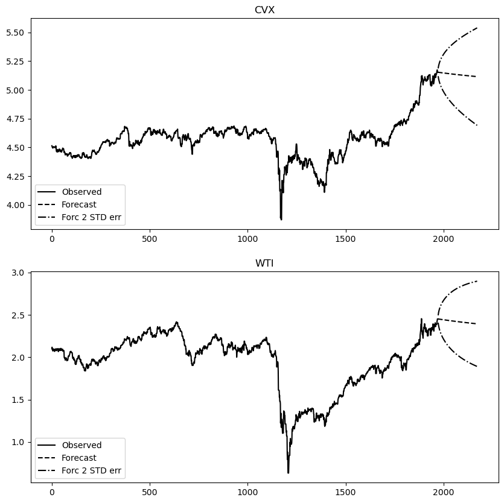

```python
results.plot_forecast(200)
plt.show()
```

Another type of multivariate time series models are state space models. This type of model treats one of the series as unobserved, or latent. A very common example of the state space approach is when we presume the observed time series has noise in it, and we want to filter out the noise to discover the "true state" of the other variable, presumed to be latent. Practical examples of this include signal processing, or realized versus potential GDP in macroeconomics.

For example, if we have the observed time series $y_t$ that is a noisy observation of the latent series $x_t$ following a random walk, a state space model could look like

$y_t = x_t + \varepsilon_t$,

$x_t = x_{t-1} + \eta_t$,

with $\varepsilon_t \sim N(0, \sigma^2_y)$, $\eta_t \sim N(0, \sigma^2_x)$ and some initial value $x_0$. As $x_t$ is not observed, we can model it as the random variable $x_t \sim N(x_{t-1}, \sigma^2_x)$, which means that the values $x_1, x_2, \ldots, x_t$ are in practice treated as parameters to be estimated. It is possible for the state variable to follow processes other than the random walk, such as an autoregressive process, for example.

The statsmodels library allows us to specify many different types of state space models. We can try fitting an unobserved components model, more specifically a local level model for the CPI inflation series

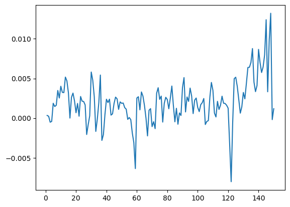

```python
cpi_infl = pd.read_csv("https://api.db.nomics.world/v22/series/BLS/cu/CUSR0000SA0.csv", index_col = 0)['2010-01-01':].pct_change()
# gdp_growth = pd.read_csv("https://api.db.nomics.world/v22/series/BEA/GDPbyIndustry-15/II-Q.csv", index_col = 0).pct_change()
plt.plot(cpi_infl.values)
```

```python
model_ll = sm.tsa.UnobservedComponents(cpi_infl, 'local level')
results_ll = model_ll.fit()
results_ll.summary()
```

Unobserved Components Results

| Dep. Variable: | U.S. city average – Current – All items – Monthly – Seasonally Adjusted (BLS/cu/CUSR0000SA0) | No. Observations: | 151 |
| --- | --- | --- | --- |
| Model: | local level | Log Likelihood | 675.338 |
| Date: | Wed, 05 Oct 2022 | AIC | -1346.677 |
| Time: | 12:13:09 | BIC | -1340.656 |
| Sample: | 02-01-2010 | HQIC | -1344.231 |
|  | - 08-01-2022 |  |  |
| Covariance Type: | opg |  |  |

|  | coef | std err | z | P>\|z\| | [0.025 | 0.975] |
| --- | --- | --- | --- | --- | --- | --- |
| sigma2.irregular | 4.582e-06 | 4.2e-07 | 10.912 | 0.000 | 3.76e-06 | 5.41e-06 |
| sigma2.level | 3.5e-07 | 1.23e-07 | 2.836 | 0.005 | 1.08e-07 | 5.92e-07 |

| Ljung-Box (L1) (Q): | 9.90 | Jarque-Bera (JB): | 26.35 |
| --- | --- | --- | --- |
| Prob(Q): | 0.00 | Prob(JB): | 0.00 |
| Heteroskedasticity (H): | 2.59 | Skew: | -0.51 |
| Prob(H) (two-sided): | 0.00 | Kurtosis: | 4.78 |

Warnings:  
[1] Covariance matrix calculated using the outer product of gradients (complex-step).

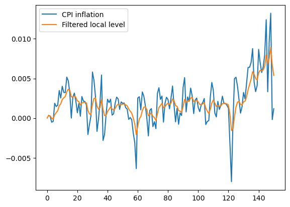

```python
plt.plot(cpi_infl.values, label= "CPI inflation")
plt.plot(results_ll.level.filtered, label="Filtered local level")
plt.legend()
```

The Kalman filter is one of the benchmark frameworks for estimating unknown latent variables from the observation of a noisy process. It can be written as an algorithm where we start with prior knowledge about the latent variable respresented as a probability distribution, and then update our knowledge with each measurement. Conceptually, the Kalman filter can be seen as Bayesian, although, as the prior and measurement (likelihood) distributions are assumed to be normal, we can get closed conjugate forms for the posteriors, and therefore Bayesian computation is not needed.

Suppose we have the state space model in the form

$\mathbf{y}_t = G \mathbf{x}_t + \boldsymbol{\varepsilon}_t$, $\boldsymbol{\varepsilon}_t \sim N(0, R)$,

$\mathbf{x}_t = F \mathbf{x}_{t-1} + \boldsymbol{\eta}_t$, $\boldsymbol{\eta}_t \sim N(0,Q)$,

where the first equation is the measurement (observation) equation, and the second is the transition (state) equation. The matrices $G$ and $F$ are responsible for the dynamics of the measurement and transition equations. If we want to apply the Kalman filter to this model, we need to start out with some prior knowledge about $\mathbf{x}_0$, summarized in the form of a normal distribution

$P(\mathbf{x}_0) \sim N(\hat{x}_0, \Sigma_0) $,

the following values for $\mathbf{x}_t$ given a past value have distribution $N(F \mathbf{x}_{t-1}, Q)$ and the measurement $\mathbf{y}_t$ given $\mathbf{x}_t$ has distribution $N(G \mathbf{x}_t, R)$, we can obtain the posterior distribution for the states $\mathbf{x}_t$ given the observations $\mathbf{y}_t$

$\mathbf{x}_t|\mathbf{y}_t \sim N(F \hat{\mathbf{x}} + F\Sigma G' (G\Sigma G' + R)^{-1} (\mathbf{y} - G \hat{\mathbf{x}}), F \Sigma F' - F\Sigma G' (G\Sigma G' + R)^{-1} G \Sigma F' + Q)$,

where $\hat{\mathbf{x}}$ is the prior mean and $\Sigma$ is the prior covariance, set to $\hat{\mathbf{x}}_0, \Sigma_0$ at the first step and updated in succession (the old posterior becomes the new prior).

The matrix $F\Sigma G' (G\Sigma G' + R)^{-1}$ is known as the Kalman gain. Intuitively, this measures how much information about the unobserved state we gain from the observed variable.

The derivations for the Kalman filter can be done in a Bayesian framework, as we did here, but, as the Kalman filter is linear and Gaussian, it is also possible to derive it in a classical, linear regression framework. For a thorough derivation, see: https://python.quantecon.org/kalman.html

The statsmodels unobserved components models already make use of Kalman filtering/smoothing routines

It turns out that the Bayesian approaches for state space modeling and the Kalman filter, are, together with feature selection, causal inference and model comparison, part of a novel modeling approach known as Bayesian structural time series (BSTS).

BSTS can be seen as a Bayesian alternative to the Box-Jenkins (ARIMA) approach, allowing for more flexibility in model specification. It allows for latent (state) variables with many different possible specifications, as in the state space approach. It can also incorporate exogenous regressors (as it was the case for ARIMA), with built-in feature selection methods such as spike-and-slab priors. Additional information may also be incorporate through the prior distribution of the parameters, and different models can be compared with techniques such as Bayesian model averaging. The BSTS models are generally estimated via MCMC algorithms.

We can propose a BSTS for the stock returns of Chevron, an oil company, with WTI crude oil and S&P 500 returns as regressors (exogeous variables) plus a state space specification for stochastic volatility. This model can then be fitted with PyMC

```python
sp = yf.Ticker("^GSPC").history(start = start_date, end = end_date)["Close"].rename("S&P 500")
sp_diff = np.log(sp).diff().dropna()

returns_df = pd.concat([cvx_diff, wti_diff, sp_diff], axis=1).dropna()

with pm.Model() as bsts_model:
    alpha = pm.Normal("Intercept", mu=0, sigma=1)
    beta_wti = pm.Normal("WTI coefficient", mu=0, sigma=1)
    beta_sp = pm.Normal("S&P 500 coefficient", mu=0, sigma=1)

    y_mean = alpha + beta_wti * returns_df["WTI"].values + beta_sp * returns_df['S&P 500'].values

    step_size = pm.HalfCauchy('step size', beta = 1)
    vol = pm.GaussianRandomWalk("volatility", sigma=step_size, shape = len(returns_df))

    y = pm.Normal("likelihood", mu=y_mean, sigma=pm.math.exp(-2 * vol), observed=returns_df['CVX'].values)
pm.model_to_graphviz(bsts_model)
```

[figure not shown]

```python
with bsts_model:
    trace_bsts = pm.sample(2000, tune=1000, return_inferencedata=True)
```

```
Auto-assigning NUTS sampler...
Initializing NUTS using jitter+adapt_diag...
Multiprocess sampling (4 chains in 4 jobs)
NUTS: [Intercept, WTI coefficient, S&P 500 coefficient, step size, volatility]
```

100.00% [12000/12000 03:26<00:00 Sampling 4 chains, 0 divergences]

```
Sampling 4 chains for 1_000 tune and 2_000 draw iterations (4_000 + 8_000 draws total) took 229 seconds.
```

```
array([[<AxesSubplot:title={'center':'Intercept'}>,
        <AxesSubplot:title={'center':'Intercept'}>],
       [<AxesSubplot:title={'center':'WTI coefficient'}>,
        <AxesSubplot:title={'center':'WTI coefficient'}>],
       [<AxesSubplot:title={'center':'S&P 500 coefficient'}>,
        <AxesSubplot:title={'center':'S&P 500 coefficient'}>],
       [<AxesSubplot:title={'center':'step size'}>,
        <AxesSubplot:title={'center':'step size'}>]], dtype=object)
```

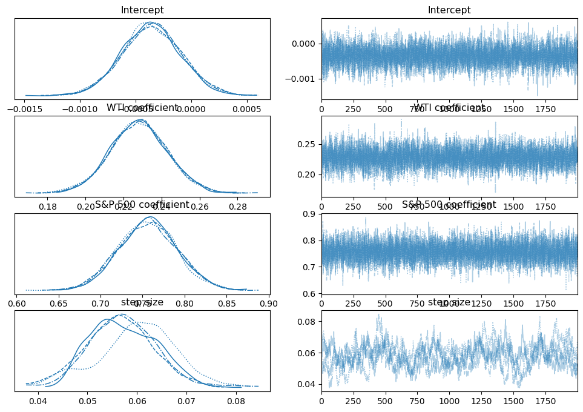

```python
az.plot_trace(trace_bsts, var_names=['~volatility'])
```

```python
az.summary(trace_bsts, var_names=["~volatility"])
```

|  | mean | sd | hdi_3% | hdi_97% | mcse_mean | mcse_sd | ess_bulk | ess_tail | r_hat |
| --- | --- | --- | --- | --- | --- | --- | --- | --- | --- |
| Intercept | -0.000 | 0.000 | -0.001 | 0.000 | 0.000 | 0.0 | 7012.0 | 6043.0 | 1.00 |
| WTI coefficient | 0.228 | 0.015 | 0.200 | 0.256 | 0.000 | 0.0 | 7973.0 | 6891.0 | 1.00 |
| S&P 500 coefficient | 0.756 | 0.035 | 0.691 | 0.822 | 0.000 | 0.0 | 8339.0 | 7170.0 | 1.00 |
| step size | 0.058 | 0.007 | 0.045 | 0.071 | 0.001 | 0.0 | 107.0 | 159.0 | 1.05 |

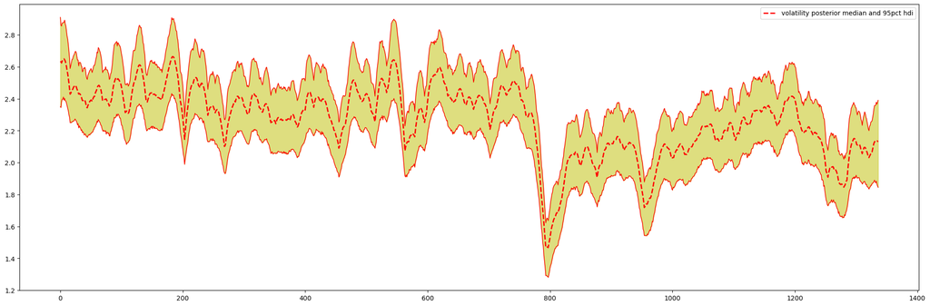

```python
posterior_median = np.median(trace_bsts.posterior.volatility.values, axis=(0,1))
posterior_hpd_lower = az.hdi(trace_bsts.posterior.volatility.values,hdi_prob=.95).T[0]
posterior_hpd_upper = az.hdi(trace_bsts.posterior.volatility.values,hdi_prob=.95).T[1]

plt.figure(figsize=(25,8))
plt.plot(posterior_median, 'r', lw=2, label="volatility posterior median and 95pct hdi", linestyle='dashed')
plt.plot(posterior_hpd_upper, "r", lw=1)
plt.plot(posterior_hpd_lower, "r", lw=1)
plt.fill_between(range(0,len(returns_df)),posterior_hpd_lower, posterior_hpd_upper, color="y", alpha=0.5)
plt.legend()
```